# Predictors of hearing aid ownership in a clinic sample

# 1. Measures available

back to top

**List**

**Demographics**: Age, Gender, Work, Volunteer, Live alone  
**Physical health**: General health rating, CLSA morbidity checklist, Subjective vision (loss, rating aided), Subjective hearing (loss, rating aided, rating unaided)  
**Hearing health**: Hearing device use, Hearing device type, Tinnitus past 7 days, 15i-SSQ, Social Isolation Measure, EmoCheQ, HHIE-S, Audiogram  
**Cognitive health**: Subjective cognitive impairment, Cognitive Self Report Questionnaire  
**Mobility and balance**: Mobility aid use, Activities and Balance Confidence scale  
**Quality of life**: Satisfaction With Life Scale, WHO-BREF  
**Mental health**: Patient Health Questionnaire-4 item (PHQ-4)  
**Social factors**: Loneliness, Social Network Index, Social Participation Frequency, Social Participation Types, Social Support (Medical Outcome Survey)  
**Views**: Connections between hearing loss and health, Motivations for seeking hearing help

# 2. Simple data cleaning

back to top

**Rules**

- For “single-item” variables (e.g. loneliness): NA’s are left as is.
- For morbidity checklist: All responses other than “yes” (NA’s, No, Don’t know) are treated as “no”.
- For subjective vision or hearing loss, “Don’t know” is recoded to NA.
- For composite variables: If a participant has “NA” for all items, the composite score is also “NA”.
- WHOQOL-BREF: Follow their protocol for NA’s.
- For SIM, EmoCheQ, CSRQ, PHQ4, Views on motivations: Impute case mean.
- For 15i-SSQ: Impute case mean within subscale.
- For HHIES: Impute case mode within subscale.
- For ABC: Recode NA’s to 0 (single participant).
- For Social Network Index: Recode NA’s to “never”.
- For Social Participation: Recode NA’s to “never”.
- For Social Support: Recode NA’s to “none”.
- For Views (Connections): Drop foil item; only correct items credited.

# 3. Missing data analysis

back to top

**Missing data by variable**

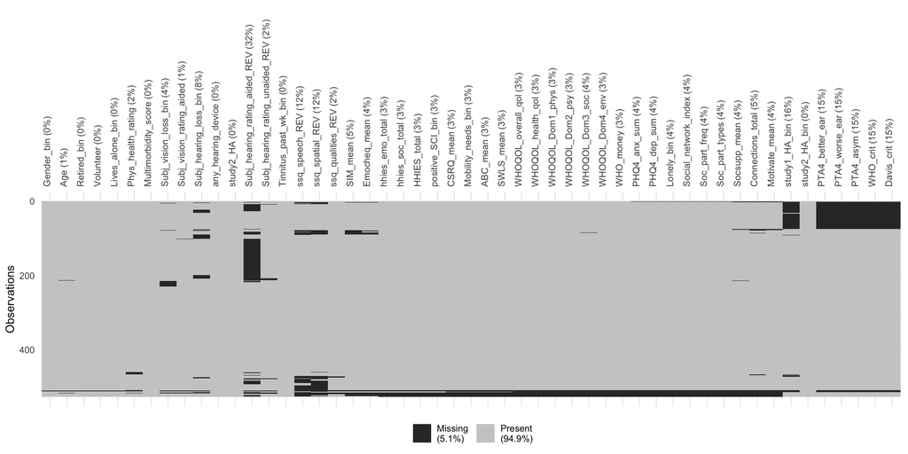

```
## # A tibble: 51 × 3
##    variable                        n_miss pct_miss
##    <chr>                            <int>    <num>
##  1 Gender_bin                           2    0.380
##  2 Age                                  5    0.949
##  3 Retired_bin                          2    0.380
##  4 Volunteer                            2    0.380
##  5 Lives_alone_bin                      2    0.380
##  6 Phys_health_rating                  11    2.09
##  7 Multimorbidity_score                 0    0
##  8 Subj_vision_loss_bin                22    4.17
##  9 Subj_vision_rating_aided             5    0.949
## 10 Subj_hearing_loss_bin               41    7.78
## 11 any_hearing_device                   0    0
## 12 study2_HA                            0    0
```

[output cut: 39 more lines]

**Missing data by person**

```
## # A tibble: 527 × 3
##     case n_miss pct_miss
##    <int>  <int>    <dbl>
##  1   458     46     90.2
##  2   467     46     90.2
##  3   228     36     70.6
##  4   483     36     70.6
##  5    77     34     66.7
##  6   153     31     60.8
##  7   166     29     56.9
##  8   192     29     56.9
##  9   364     29     56.9
## 10   176     28     54.9
## 11   187     28     54.9
## 12   318     28     54.9
```

[output cut: 19 more lines]

# 3. Missing data imputation

back to top

**Which variables need imputation?**

```
##                           Variable Missing_n
## 1                       Gender_bin         0
## 2                              Age         3
## 3                      Retired_bin         0
## 4                    Volunteer_rec         0
## 5                  Lives_alone_bin         0
## 6               Phys_health_rating         9
## 7             Multimorbidity_score         0
## 8             Subj_vision_loss_bin        20
## 9         Subj_vision_rating_aided         3
## 10           Subj_hearing_loss_bin        39
## 11   Subj_hearing_rating_aided_REV       167
## 12 Subj_hearing_rating_unaided_REV        11
## 13            Tinnitus_past_wk_bin         0
## 14                  ssq_speech_REV        59
```

[output cut: 34 more lines]

**Method for imputation**

*under construction*

- Use predictors that correlate 0.5 or better to impute missing data in a variable. If there are no such predictors, adjust threshold to 0.4, then 0.3, then 0.2.
- MICE settings: total of 5 imputed datasets, with a maximum of 10 iterations per dataset, using predictive means matching to impute missing values.

# 4. Entire sample

back to top

Entire sample: n=525  
Complete cases for 43 predictors and 1 outcome: n=232

**Process of eliminating some of 43 predictors, using VIF**

```
##                                 Variance_inflation_factor
## Gender_bin                                     119.670716
## Age                                            136.387021
## Retired_bin                                     57.982059
## Volunteer_rec                                   93.894248
## Lives_alone_bin                                 90.556242
## Phys_health_rating                              41.974877
## Multimorbidity_score                            35.032328
## Mobility_needs_bin                              24.753010
## ABC_mean                                        25.984096
## Subj_vision_loss_bin                            51.645677
## Subj_vision_rating_aided                       101.939289
## Subj_hearing_loss_bin                            9.766726
## Subj_hearing_rating_unaided_REV                 92.333864
## Subj_hearing_rating_aided_REV                  138.712181
## Tinnitus_past_wk_bin                            51.190892
## PTA4_better_ear                                 69.772055
## PTA4_asym                                       25.644809
## ssq_speech_REV                                 114.296359
## ssq_spatial_REV                                 48.407360
## ssq_qualities_REV                               68.371093
## SIM_mean                                        58.348838
## Emocheq_mean                                    64.578268
## hhies_emo_total                                 92.279720
## hhies_soc_total                                 99.343561
## positive_SCI_bin                                46.293127
## CSRQ_mean                                       95.449284
## SWLS_mean                                      155.878760
## WHOQOL_overall_qol                              94.397907
## WHOQOL_health_qol                              123.331391
## WHOQOL_Dom1_phys                               136.031132
## WHOQOL_Dom2_psy                                 84.450305
## WHOQOL_Dom3_soc                                 77.011564
## WHOQOL_Dom4_env                                205.618625
## WHO_money                                      108.670171
## PHQ4_anx_sum                                   132.423438
## PHQ4_dep_sum                                   148.734369
## Lonely_bin                                      61.517265
## Social_network_index                            42.518838
## Soc_part_freq                                   40.268684
## Soc_part_types                                 132.120585
## Socsupp_mean                                    95.057005
## Connections_total                               31.187476
## Motivate_mean                                   50.937449
```

```
##                                 Variance_inflation_factor
## Gender_bin                                       2.476344
## Age                                              2.515184
## Retired_bin                                      2.356721
## Volunteer_rec                                    2.183201
## Lives_alone_bin                                  2.469347
## Phys_health_rating                               3.384317
## Multimorbidity_score                             3.333548
## Mobility_needs_bin                               2.656427
## ABC_mean                                         2.812852
## Subj_vision_rating_aided                         1.968986
## Subj_hearing_rating_unaided_REV                  2.238305
## Tinnitus_past_wk_bin                             1.559114
## PTA4_better_ear                                  2.521443
## ssq_speech_REV                                   3.718055
## ssq_spatial_REV                                  2.995585
## ssq_qualities_REV                                2.644613
## SIM_mean                                         5.880561
## Emocheq_mean                                     3.858019
## hhies_emo_total                                  4.849560
## hhies_soc_total                                  3.827710
## positive_SCI_bin                                 2.174259
## CSRQ_mean                                        3.966182
## WHOQOL_overall_qol                               5.449339
## WHOQOL_health_qol                                5.150708
## WHOQOL_Dom1_phys                                 6.210290
## WHOQOL_Dom2_psy                                  8.860626
## WHOQOL_Dom3_soc                                  5.005031
## WHOQOL_Dom4_env                                  5.578987
## WHO_money                                        3.178715
## PHQ4_anx_sum                                     3.661532
## PHQ4_dep_sum                                     5.542634
## Lonely_bin                                       3.102023
## Social_network_index                             3.529858
## Soc_part_freq                                    3.016795
## Soc_part_types                                   5.581772
## Socsupp_mean                                     2.801976
## Connections_total                                1.932110
## Motivate_mean                                    2.082755
```

```
##                                 Variance_inflation_factor
## Gender_bin                                       2.251440
## Age                                              2.500306
## Retired_bin                                      2.223325
## Volunteer_rec                                    2.032646
## Lives_alone_bin                                  2.498419
## Phys_health_rating                               3.288180
## Multimorbidity_score                             2.675553
## Mobility_needs_bin                               2.558704
## ABC_mean                                         2.809248
## Subj_vision_rating_aided                         1.826123
## Subj_hearing_rating_unaided_REV                  1.946710
## Tinnitus_past_wk_bin                             1.384603
## PTA4_better_ear                                  2.337295
## ssq_speech_REV                                   3.436023
## ssq_spatial_REV                                  2.861361
## ssq_qualities_REV                                2.590571
## Emocheq_mean                                     3.084190
## hhies_emo_total                                  4.233769
## hhies_soc_total                                  3.328112
## positive_SCI_bin                                 2.006393
## CSRQ_mean                                        3.950615
## WHOQOL_health_qol                                4.763256
## WHOQOL_Dom1_phys                                 5.978081
## WHOQOL_Dom2_psy                                  7.479542
## WHOQOL_Dom3_soc                                  4.896284
## WHOQOL_Dom4_env                                  5.176630
## WHO_money                                        3.113610
## PHQ4_anx_sum                                     3.417205
## PHQ4_dep_sum                                     5.280280
## Lonely_bin                                       2.959666
## Social_network_index                             3.579923
## Soc_part_freq                                    2.900556
## Soc_part_types                                   5.248955
## Socsupp_mean                                     2.754423
## Connections_total                                1.760319
## Motivate_mean                                    2.031243
```

```
##                                 Variance_inflation_factor
## Gender_bin                                       1.987615
## Age                                              2.261276
## Retired_bin                                      1.876570
## Volunteer_rec                                    1.785504
## Lives_alone_bin                                  2.161568
## Phys_health_rating                               3.335340
## Multimorbidity_score                             2.665439
## Mobility_needs_bin                               2.333920
## ABC_mean                                         2.409617
## Subj_vision_rating_aided                         1.714904
## Subj_hearing_rating_unaided_REV                  1.902950
## Tinnitus_past_wk_bin                             1.405799
## PTA4_better_ear                                  1.883329
## ssq_speech_REV                                   3.115193
## ssq_spatial_REV                                  2.244286
## ssq_qualities_REV                                2.453894
## Emocheq_mean                                     2.804099
## hhies_emo_total                                  3.846576
## hhies_soc_total                                  3.062317
## positive_SCI_bin                                 1.996570
## CSRQ_mean                                        4.357946
## WHOQOL_health_qol                                3.770669
## WHO_money                                        2.104830
## PHQ4_anx_sum                                     3.613661
## PHQ4_dep_sum                                     4.960707
## Lonely_bin                                       2.722882
## Social_network_index                             3.427762
## Soc_part_freq                                    2.844740
## Soc_part_types                                   4.085661
## Socsupp_mean                                     2.253590
## Connections_total                                1.671100
## Motivate_mean                                    2.063921
```

**Results for model with 32 predictors, n=232**

```
##                               Term Estimate StdError       z      p OddsRatio CIlower CIupper sig
## 1                      (Intercept) -24.0577   7.7576 -3.1012 0.0019         0       0   1e-04
## 2                       Gender_bin  -0.0654   0.6944 -0.0942  0.925    0.9367  0.2402  3.6534
## 3                              Age   0.0332    0.049  0.6766 0.4986    1.0337  0.9391  1.1379
## 4                      Retired_bin  -0.0676    0.695 -0.0973 0.9225    0.9346  0.2394  3.6496
## 5                    Volunteer_rec   0.7642   0.3848  1.9861  0.047    2.1472  1.0101  4.5643   *
## 6                  Lives_alone_bin   0.4499   0.8369  0.5376 0.5908    1.5682  0.3041   8.086
## 7               Phys_health_rating   0.1967   0.5536  0.3554 0.7223    1.2174  0.4114  3.6029
## 8             Multimorbidity_score  -0.1116   0.1606 -0.6953 0.4869    0.8944  0.6529  1.2252
## 9               Mobility_needs_bin   0.0235   1.4439  0.0163  0.987    1.0238  0.0604 17.3481
## 10                        ABC_mean   -5e-04   0.0267 -0.0185 0.9852    0.9995  0.9486  1.0532
## 11        Subj_vision_rating_aided   0.7307   0.4318  1.6921 0.0906    2.0765  0.8908  4.8403
## 12 Subj_hearing_rating_unaided_REV   1.4386   0.4711  3.0535 0.0023     4.215   1.674 10.6128   *
## 13            Tinnitus_past_wk_bin  -0.3231   0.5857 -0.5517 0.5811    0.7239  0.2297  2.2813
## 14                 PTA4_better_ear   0.1958   0.0448  4.3662      0    1.2163  1.1139   1.328   *
```

[output cut: 19 more lines]

**Check VIF**

```
##                                 Variance_inflation_factor
## Gender_bin                                       1.987615
## Age                                              2.261276
## Retired_bin                                      1.876570
## Volunteer_rec                                    1.785504
## Lives_alone_bin                                  2.161568
## Phys_health_rating                               3.335340
## Multimorbidity_score                             2.665439
## Mobility_needs_bin                               2.333920
## ABC_mean                                         2.409617
## Subj_vision_rating_aided                         1.714904
## Subj_hearing_rating_unaided_REV                  1.902950
## Tinnitus_past_wk_bin                             1.405799
## PTA4_better_ear                                  1.883329
## ssq_speech_REV                                   3.115193
## ssq_spatial_REV                                  2.244286
## ssq_qualities_REV                                2.453894
## Emocheq_mean                                     2.804099
## hhies_emo_total                                  3.846576
## hhies_soc_total                                  3.062317
## positive_SCI_bin                                 1.996570
## CSRQ_mean                                        4.357946
## WHOQOL_health_qol                                3.770669
## WHO_money                                        2.104830
## PHQ4_anx_sum                                     3.613661
## PHQ4_dep_sum                                     4.960707
## Lonely_bin                                       2.722882
## Social_network_index                             3.427762
## Soc_part_freq                                    2.844740
## Soc_part_types                                   4.085661
## Socsupp_mean                                     2.253590
## Connections_total                                1.671100
## Motivate_mean                                    2.063921
```

# 5. “WHO” subgroup

back to top

Better ear >25 dB HL 4f-PTA: n=167  
Complete data with 32 predictors and 1 outcome: n=135

**Results for model with 32 predictors, n=135**

```
##                               Term Estimate StdError       z      p OddsRatio CIlower   CIupper sig
## 1                      (Intercept) -24.0795   10.807 -2.2282 0.0259         0       0    0.0551
## 2                       Gender_bin   1.2685   0.8467  1.4981 0.1341    3.5556  0.6763   18.6915
## 3                              Age   0.0549   0.0583  0.9413 0.3466    1.0564  0.9424    1.1842
## 4                      Retired_bin  -1.8253    0.931 -1.9606 0.0499    0.1612   0.026    0.9994   *
## 5                    Volunteer_rec    1.255     0.53   2.368 0.0179    3.5079  1.2414    9.9119   *
## 6                  Lives_alone_bin  -1.4691   0.9953  -1.476 0.1399    0.2301  0.0327    1.6188
## 7               Phys_health_rating   0.8816   0.7221  1.2209 0.2221    2.4147  0.5865    9.9426
## 8             Multimorbidity_score  -0.1304    0.213  -0.612 0.5405    0.8778  0.5782    1.3326
## 9               Mobility_needs_bin   2.9502   2.2601  1.3053 0.1918   19.1089  0.2277 1603.5239
## 10                        ABC_mean  -0.0034   0.0512 -0.0673 0.9463    0.9966  0.9014    1.1018
## 11        Subj_vision_rating_aided  -0.6599    0.538 -1.2266   0.22    0.5169  0.1801    1.4837
## 12 Subj_hearing_rating_unaided_REV   1.0162    0.593  1.7137 0.0866    2.7628  0.8641    8.8331
## 13            Tinnitus_past_wk_bin  -0.6349   0.7383   -0.86 0.3898      0.53  0.1247    2.2526
## 14                 PTA4_better_ear    0.256   0.0847   3.024 0.0025    1.2917  1.0943    1.5249   *
```

[output cut: 19 more lines]

**Check VIF**

```
##                                 Variance_inflation_factor
## Gender_bin                                       2.485576
## Age                                              2.723640
## Retired_bin                                      2.581167
## Volunteer_rec                                    2.766388
## Lives_alone_bin                                  2.278792
## Phys_health_rating                               4.927637
## Multimorbidity_score                             3.124149
## Mobility_needs_bin                               4.225251
## ABC_mean                                         5.179210
## Subj_vision_rating_aided                         2.598338
## Subj_hearing_rating_unaided_REV                  2.309268
## Tinnitus_past_wk_bin                             1.714126
## PTA4_better_ear                                  2.241612
## ssq_speech_REV                                   5.431694
## ssq_spatial_REV                                  3.507440
## ssq_qualities_REV                                4.190605
## Emocheq_mean                                     3.301181
## hhies_emo_total                                  4.313791
## hhies_soc_total                                  3.817126
## positive_SCI_bin                                 2.978926
## CSRQ_mean                                        3.784704
## WHOQOL_health_qol                                4.921532
## WHO_money                                        2.272824
## PHQ4_anx_sum                                     6.502703
## PHQ4_dep_sum                                     5.534622
## Lonely_bin                                       3.356156
## Social_network_index                             3.211609
## Soc_part_freq                                    2.589596
## Soc_part_types                                   2.476304
## Socsupp_mean                                     3.034152
## Connections_total                                2.105246
## Motivate_mean                                    2.055088
```

**LASSO regression, n=135**

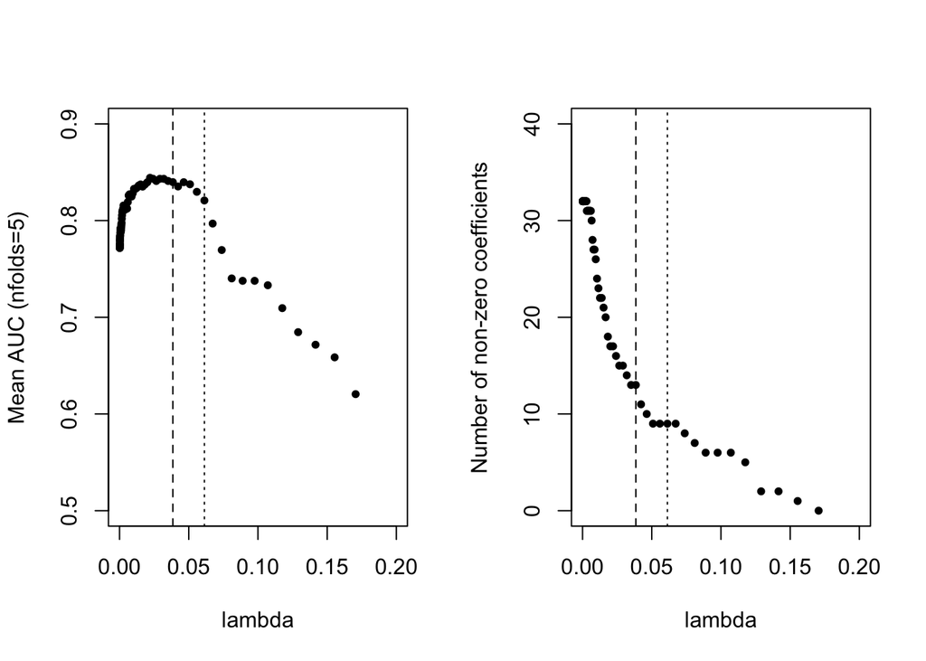

```
##
## Call:  cv.glmnet(x = as.matrix(data_WHO_complete[, 1:32]), y = data_WHO_complete$study2_HA_bin,      type.measure = "auc", nfolds = 5, family = "binomial")
##
## Measure: AUC
##
##      Lambda Index Measure      SE Nonzero
## min 0.02203    23  0.8442 0.03159      17
## 1se 0.06130    12  0.8208 0.03190       9
```

```
## 33 x 1 sparse Matrix of class "dgCMatrix"
##                                           s1
## (Intercept)                     -9.203462182
## Gender_bin                       .
## Age                              .
## Retired_bin                     -0.087700724
## Volunteer_rec                    0.299537113
## Lives_alone_bin                 -0.590242461
## Phys_health_rating               .
## Multimorbidity_score             .
## Mobility_needs_bin               .
## ABC_mean                        -0.002121481
## Subj_vision_rating_aided         .
## Subj_hearing_rating_unaided_REV  0.584434556
## Tinnitus_past_wk_bin            -0.061396097
## PTA4_better_ear                  0.111419102
## ssq_speech_REV                  -0.255536031
## ssq_spatial_REV                 -0.177453159
## ssq_qualities_REV                .
## Emocheq_mean                    -0.096462805
## hhies_emo_total                  0.047883259
## hhies_soc_total                  .
## positive_SCI_bin                 0.341449968
## CSRQ_mean                        .
## WHOQOL_health_qol                0.146839109
## WHO_money                        0.507981195
## PHQ4_anx_sum                     0.473781625
## PHQ4_dep_sum                     .
## Lonely_bin                       .
## Social_network_index             .
## Soc_part_freq                    .
## Soc_part_types                   .
## Socsupp_mean                     0.262863850
## Connections_total               -0.063854224
## Motivate_mean                    .
```

```
##                               Term Estimate StdError       z      p OddsRatio CIlower CIupper sig
## 1                      (Intercept) -18.0919   4.1062 -4.4059      0         0       0       0
## 2                    Volunteer_rec   0.6031    0.314  1.9209 0.0547    1.8278  0.9878   3.382
## 3                  Lives_alone_bin  -1.0269   0.6547 -1.5686 0.1168    0.3581  0.0993  1.2921
## 4  Subj_hearing_rating_unaided_REV   1.1506   0.4662  2.4681 0.0136    3.1602  1.2673  7.8804   *
## 5             Tinnitus_past_wk_bin  -0.3419   0.5595  -0.611 0.5412    0.7104  0.2373   2.127
## 6                  PTA4_better_ear   0.1936   0.0581  3.3318  9e-04    1.2136   1.083  1.3599   *
## 7                   ssq_speech_REV  -0.4378   0.2004 -2.1846 0.0289    0.6455  0.4358   0.956   *
## 8                  ssq_spatial_REV  -0.2897   0.2191 -1.3221 0.1861    0.7485  0.4872    1.15
## 9                  hhies_emo_total   0.1111   0.0767  1.4488 0.1474    1.1175  0.9616  1.2986
## 10                positive_SCI_bin    1.325   0.8973  1.4766 0.1398    3.7621  0.6481 21.8384
## 11               WHOQOL_health_qol   0.4261   0.3366  1.2662 0.2054    1.5313  0.7918  2.9618
## 12                       WHO_money   1.0336   0.4009  2.5782 0.0099    2.8111  1.2812  6.1675   *
## 13                    PHQ4_anx_sum   0.8799   0.2735  3.2167 0.0013    2.4106  1.4102  4.1206   *
## 14                    Socsupp_mean   0.3514   0.3547  0.9907 0.3218     1.421  0.7091  2.8476
## 15               Connections_total  -0.1834   0.1562 -1.1739 0.2405    0.8324  0.6129  1.1307
```

**Plots of PHQ4 anxiety subscore**

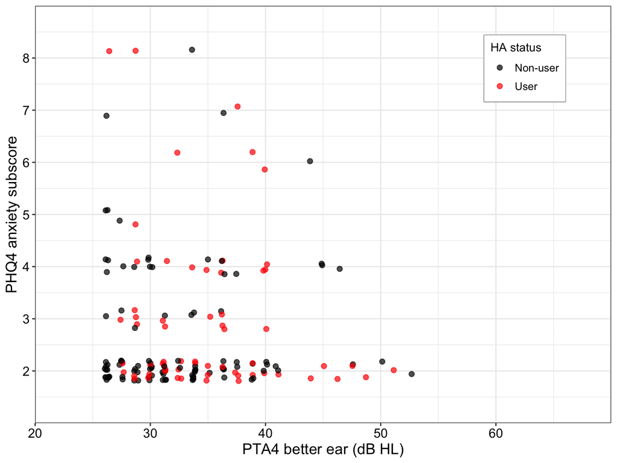

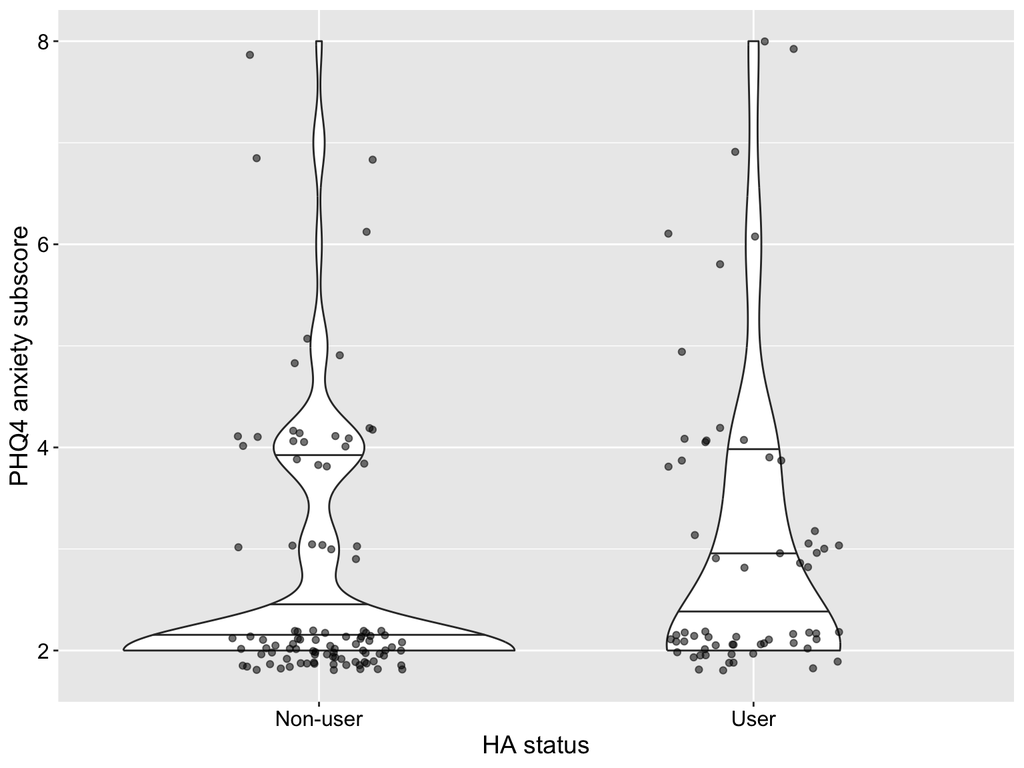

# 6. “Davis” subgroup

back to top

Better ear ≥35 dB HL @ 3kHz: n=78  
Complete cases for 32 predictors & 1 outcome: n=65

**Results for model with 32 predictors, n=65**

*too few datapoints for the number of predictors*

**Check VIF**

*problematic*

**Results for model with 6 predictors, n=65**

Note: 6 predictors that were significant in the WHO model.

```
##              Term Estimate StdError       z      p OddsRatio CIlower CIupper sig
## 1     (Intercept) -11.1603   3.9538 -2.8227 0.0048         0       0   0.033
## 2     Retired_bin   0.2936   0.7281  0.4033 0.6867    1.3413  0.3219  5.5877
## 3   Volunteer_rec   0.4447    0.394  1.1285 0.2591      1.56  0.7206  3.3768
## 4 PTA4_better_ear   0.1532   0.0809  1.8941 0.0582    1.1655  0.9947  1.3657
## 5    Emocheq_mean  -0.9828    0.481 -2.0433  0.041    0.3743  0.1458  0.9607   *
## 6       WHO_money   1.1676   0.4406  2.6499 0.0081    3.2142  1.3552  7.6229   *
## 7    PHQ4_anx_sum   1.0374   0.3978  2.6081 0.0091    2.8218  1.2941  6.1533   *
```

**Check VIF**

```
##                 Variance_inflation_factor
## Retired_bin                      1.094362
## Volunteer_rec                    1.042364
## PTA4_better_ear                  1.157190
## Emocheq_mean                     1.796944
## WHO_money                        1.549627
## PHQ4_anx_sum                     1.866931
```

# 7. Summary

back to top

How consistent is the effect of anxiety?

- Having greater anxiety predicts HA ownership, in the bigger sample with mixed hearing, and in the smaller samples limited to HA candidates only

Besides anxiety, what are other consistent predictors of HA ownership?

- The WHO-BREF question on “having enough money for your needs”, for all three samples
- EmoCheQ, for HA candidates only (i.e. WHO, Davis)
- Volunteering, in the mixed and WHO samples
- PTA4BE, in the mixed and WHO samples